# alazygatr_vignette

Install all of the required packages:

```r
# Install packages for installing other packages
if (!require("devtools", quietly = TRUE)) install.packages("devtools")
if (!require("BiocManager", quietly = TRUE)) install.packages("BiocManager")

# For genetic distance processing
if (!require("adegenet", quietly = TRUE)) install.packages("adegenet")
if (!require("Assoctests", quietly = TRUE)) install.packages("Assoctests")
if (!require("readr", quietly = TRUE)) install.packages("readr")
if (!require("tibble", quietly = TRUE)) install.packages("tibble")
if (!require("ecodist", quietly = TRUE)) install.packages("ecodist")
if (!require("cowplot", quietly = TRUE)) install.packages("cowplot")

# For genetic data processing
if (!require("gdsfmt", quietly = TRUE)) BiocManager::install("gdsfmt")
if (!require("SeqArray", quietly = TRUE)) BiocManager::install("SeqArray")
if (!require("SNPRelate", quietly = TRUE)) BiocManager::install("SNPRelate")

# For environmental and geographic data processing:
if (!require("RStoolbox", quietly = TRUE))devtools::install_github("bleutner/RStoolbox")
if (!require("geodata", quietly = TRUE)) install.packages("geodata")
if (!require("corrplot", quietly = TRUE)) install.packages("corrplot")
if (!require("vegan", quietly = TRUE)) install.packages("vegan")
if (!require("gdistance", quietly = TRUE)) install.packages("gdistance")
if (!require("topoDistance", quietly = TRUE)) install.packages("topoDistance")
if (!require("rmapshaper", quietly = TRUE)) install.packages("rmapshaper")
if (!require("wingen", quietly = TRUE)) devtools::github_install("wingen")

# For LFMM:
if (!require("adegenet", quietly = TRUE)) install.packages("adegenet")
if (!require("Assoctests", quietly = TRUE)) install.packages("Assoctests")
if (!require("lfmm", quietly = TRUE)) install.packages("lfmm")
if (!require("TESS3_encho_sen", quietly = TRUE)) devtools::install_github("bcm-uga/TESS3_encho_sen")
if (!require("LEA", quietly = TRUE)) BiocManager::install("LEA")
if (!require("tess3r", quietly = TRUE)) install.packages("tess3r")

# For RDA:
if (!require("ggrepel", quietly = TRUE)) install.packages("ggrepel")
if (!require("qvalue", quietly = TRUE)) BiocManager::install("qvalue")
if (!require("robust", quietly = TRUE)) install.packages("robust")
if (!require("tibble", quietly = TRUE)) install.packages("tibble")
if (!require("vegan", quietly = TRUE)) install.packages("vegan")

# For GDM:
if (!require("cowplot", quietly = TRUE)) install.packages("cowplot")
if (!require("gdm", quietly = TRUE)) install.packages("gdm")

# For MMRR:
if (!require("GGally", quietly = TRUE)) install.packages("GGally")

# For TESS:
if (!require("automap", quietly = TRUE)) install.packages("automap")
if (!require("graphics", quietly = TRUE)) install.packages("graphics")
if (!require("LEA", quietly = TRUE)) BiocManager::install("LEA") # required by tess3r
if (!require("TESS3_encho_sen", quietly = TRUE)) devtools::install_github("bcm-uga/TESS3_encho_sen")
if (!require("LEA", quietly = TRUE)) BiocManager::install("LEA")
if (!require("fields", quietly = TRUE)) install.packages("fields")
if (!require("rworldmap", quietly = TRUE)) install.packages("rworldmap")
if (!require("tess3r", quietly = TRUE)) install.packages("tess3r")

# For wingen:
if (!require("wingen", quietly = TRUE)) devtools::github_install("AnushaPB/wingen")
```

Are you a lazy algatr? The `do_everything_for_me()` function runs all six landscape genomic methods in the algatr package (wingen, TESS, GDM, MMRR, RDA, and LFMM) and provides limited options for customizability. This function primarily exists for fun and to demonstrate that algatr really can be run using on a vcf and sampling coordinates; we **do not** encourage researchers to actually perform analyses on their data using this function!

The main arguments within this function are simple: `vcf` specifies the vcf, `coords` specifies the sampling coordinates, and `envlayers` specifies the environmental layers (not required). As usual, make sure your samples are in the same order between your data file and coordinates file and that your CRS is consistent!

First, let’s load our test data. For the sake of things running quickly, let’s run this function on only 20 individuals from the test dataset.

```r
load_algatr_example()
```

```
##
## ---------------- example dataset ----------------
##
## Objects loaded:
## *liz_vcf* vcfR object (1000 loci x 53 samples)
## *liz_gendist* genetic distance matrix (Plink Distance)
## *liz_coords* dataframe with x and y coordinates
## *CA_env* RasterStack with PC environmental layers
##
## -------------------------------------------------
##
```

```r
gen <- liz_vcf[, 1:21]
```

```
##
##    *****       ***   vcfR   ***       *****
##      browseVignettes('vcfR') # Documentation
##      citation('vcfR') # Citation
##    *****       *****      *****       *****
```

```r
coords <- liz_coords[1:20, ]
envlayers <- CA_env
```

Now, let’s run the function:

```r
lazy_results <- do_everything_for_me(gen, coords, envlayers, quiet = FALSE)
```

```
## Please be aware: the do_everything functions are meant to be exploratory. We do not recommend their use for final analyses unless certain they are properly parameterized.
```

```
## Please be aware: the do_everything functions are meant to be exploratory. We do not recommend their use for final analyses unless certain they are properly parameterized.
```

[output not shown]

```
## terra 1.7.39
```

[output not shown]

```
## [using ordinary kriging]
```

```
## CRS do not match
```

```
## [1] 1
##
##                                  .lxk:
##                                 'x0kXXc
##                              .;dXMMMMMO.
##                          .,lkXWMMMWNWO'
##    .;clool:.      ..,clox0NMMMWXXXo\/
##   dXWKxxWKKKxoodkOKNWMMMMMMXO0k\/
##   MM0xxOxMMMMMMMMMMMMMWOdkc\/
##   MMXxxxxMMMMMMMWMXdldkc\/      wingen done!
##   MMMMMMMMMMMN0xooo;\/
##   MMMMMMMMMMWOoc/\ /\ /\ /\ /\ /\ /\ /\ /\
##   MMAPBMMMMMMMMMMEACMMMWWMWWWMIJWWWWWWKXWX
## ~~~ WWWWWWWWWWWWWWWWWWWWWWWWWWWWWWWWWWWWW ~~~
##  ~~~~~~~~~~~~~~~~~~~~~~~~~~~~~~~~~~~~~~~~~~~
##   ~~~~~~~~~~~~~~~~~~~~~~~~~~~~~~~~~~~~~~~~
##
```

```
## Please be aware: the do_everything functions are meant to be exploratory. We do not recommend their use for final analyses unless certain they are properly parameterized.
```

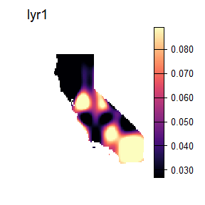

[output not shown]

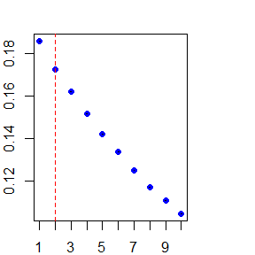

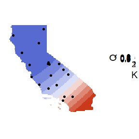

```
##
##                                  .lxk:
##                                 'x0kXXc
##                              .;dXMMMMMO.
##                          .,lkXWMMMWNWO'
##    .;clool:.      ..,clox0NMMMWXXXo\/
##   dXWKxxWKKKxoodkOKNWMMMMMMXO0k\/
##   MM0xxOxMMMMMMMMMMMMMWOdkc\/
##   MMXxxxxMMMMMMMWMXdldkc\/      TESS done!
##   MMMMMMMMMMMN0xooo;\/
##   MMMMMMMMMMWOoc/\ /\ /\ /\ /\ /\ /\ /\ /\
##   MMAPBMMMMMMMMMMEACMMMWWMWWWMIJWWWWWWKXWX
## ~~~ WWWWWWWWWWWWWWWWWWWWWWWWWWWWWWWWWWWWW ~~~
##  ~~~~~~~~~~~~~~~~~~~~~~~~~~~~~~~~~~~~~~~~~~~
##   ~~~~~~~~~~~~~~~~~~~~~~~~~~~~~~~~~~~~~~~~
##
```

```
## Please be aware: the do_everything functions are meant to be exploratory. We do not recommend their use for final analyses unless certain they are properly parameterized.
```

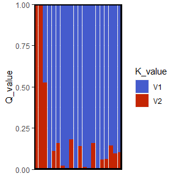

```
##       ID(p) CA_rPCA1(p) CA_rPCA2(p) CA_rPCA3(p)  geodist(p)
##  0.66336634  0.13861386  0.08910891  0.21782178  0.00990099
## CA_rPCA1(p) CA_rPCA2(p) CA_rPCA3(p)  geodist(p)
##  0.06930693  0.05940594  0.21782178  0.00990099
## CA_rPCA1(p) CA_rPCA2(p)  geodist(p)
##  0.11881188  0.14851485  0.00990099
## CA_rPCA1(p)  geodist(p)
##  0.11881188  0.00990099
```

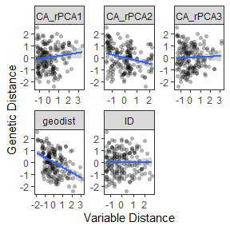

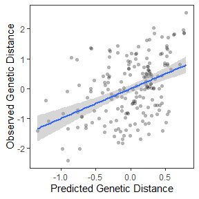

[output not shown]

[output cut: 449 more lines]

```
##                                  .lxk:
##                                 'x0kXXc
##                              .;dXMMMMMO.
##                          .,lkXWMMMWNWO'
##    .;clool:.      ..,clox0NMMMWXXXo\/
##   dXWKxxWKKKxoodkOKNWMMMMMMXO0k\/
##   MM0xxOxMMMMMMMMMMMMMWOdkc\/
##   MMXxxxxMMMMMMMWMXdldkc\/      MMRR done!
##   MMMMMMMMMMMN0xooo;\/
##   MMMMMMMMMMWOoc/\ /\ /\ /\ /\ /\ /\ /\ /\
##   MMAPBMMMMMMMMMMEACMMMWWMWWWMIJWWWWWWKXWX
## ~~~ WWWWWWWWWWWWWWWWWWWWWWWWWWWWWWWWWWWWW ~~~
##  ~~~~~~~~~~~~~~~~~~~~~~~~~~~~~~~~~~~~~~~~~~~
##   ~~~~~~~~~~~~~~~~~~~~~~~~~~~~~~~~~~~~~~~~
##
```

```
## Please be aware: the do_everything functions are meant to be exploratory. We do not recommend their use for final analyses unless certain they are properly parameterized.
```

```
## Fitting initial model with all 4 predictors...
```

```
## Sum of I-spline coefficients for predictor CA_rPCA2 = 0
```

```
## Sum of I-spline coefficients for predictor matrix_1 = 0
```

```
## Removing CA_rPCA2 and proceeding with permutation testing...
```

```
## Removing matrix_1 and proceeding with permutation testing...
```

```
## Creating 50 permuted site-pair tables...
```

```
## Starting model assessment...
```

```
## Percent deviance explained by the full model =  10.742
```

```
## Fitting GDMs to the permuted site-pair tables...
```

```
## Assessing importance of CA_rPCA1...
```

```
## Assessing importance of CA_rPCA3...
```

```
## Error: Only one predictor remains...variable assessment stopped.
```

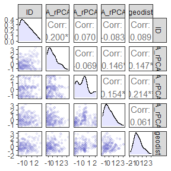

[output not shown]

[output cut: 419 more lines]

[output not shown]

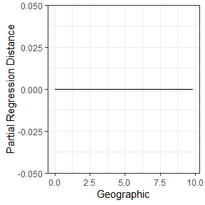

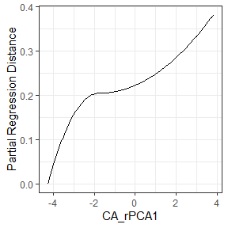

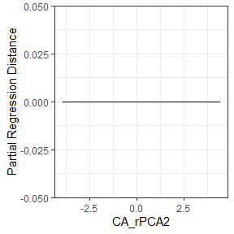

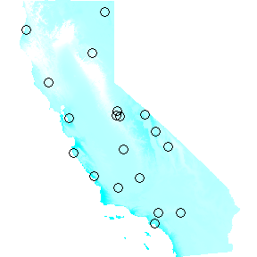

```
##
##                                  .lxk:
##                                 'x0kXXc
##                              .;dXMMMMMO.
##                          .,lkXWMMMWNWO'
##    .;clool:.      ..,clox0NMMMWXXXo\/
##   dXWKxxWKKKxoodkOKNWMMMMMMXO0k\/
##   MM0xxOxMMMMMMMMMMMMMWOdkc\/
##   MMXxxxxMMMMMMMWMXdldkc\/      GDM done!
##   MMMMMMMMMMMN0xooo;\/
##   MMMMMMMMMMWOoc/\ /\ /\ /\ /\ /\ /\ /\ /\
##   MMAPBMMMMMMMMMMEACMMMWWMWWWMIJWWWWWWKXWX
## ~~~ WWWWWWWWWWWWWWWWWWWWWWWWWWWWWWWWWWWWW ~~~
##  ~~~~~~~~~~~~~~~~~~~~~~~~~~~~~~~~~~~~~~~~~~~
##   ~~~~~~~~~~~~~~~~~~~~~~~~~~~~~~~~~~~~~~~~
##
```

```
## Please be aware: the do_everything functions are meant to be exploratory. We do not recommend their use for final analyses unless certain they are properly parameterized.
```

[figure not shown]

```
## Step: R2.adj= 0
## Call: gen ~ 1
##
##                 R2.adjusted
## <All variables>  0.03874576
## + CA_rPCA2       0.02513629
## + CA_rPCA3       0.01140016
## <none>           0.00000000
## + CA_rPCA1      -0.01190880
##
##            Df    AIC      F Pr(>F)
## + CA_rPCA2  1 99.916 1.4899  0.042 *
## ---
## Signif. codes:  0 '***' 0.001 '**' 0.01 '*' 0.05 '.' 0.1 ' ' 1
##
## Step: R2.adj= 0.02513629
## Call: gen ~ CA_rPCA2
##
##                 R2.adjusted
## + CA_rPCA3       0.05199575
## <All variables>  0.03874576
## <none>           0.02513629
## + CA_rPCA1       0.01301261
```

[figure not shown]

[output not shown]

[output cut: 457 more lines]

```
##                                  .lxk:
##                                 'x0kXXc
##                              .;dXMMMMMO.
##                          .,lkXWMMMWNWO'
##    .;clool:.      ..,clox0NMMMWXXXo\/
##   dXWKxxWKKKxoodkOKNWMMMMMMXO0k\/
##   MM0xxOxMMMMMMMMMMMMMWOdkc\/
##   MMXxxxxMMMMMMMWMXdldkc\/      RDA done!
##   MMMMMMMMMMMN0xooo;\/
##   MMMMMMMMMMWOoc/\ /\ /\ /\ /\ /\ /\ /\ /\
##   MMAPBMMMMMMMMMMEACMMMWWMWWWMIJWWWWWWKXWX
## ~~~ WWWWWWWWWWWWWWWWWWWWWWWWWWWWWWWWWWWWW ~~~
##  ~~~~~~~~~~~~~~~~~~~~~~~~~~~~~~~~~~~~~~~~~~~
##   ~~~~~~~~~~~~~~~~~~~~~~~~~~~~~~~~~~~~~~~~
##
```

```
## Please be aware: the do_everything functions are meant to be exploratory. We do not recommend their use for final analyses unless certain they are properly parameterized.
```

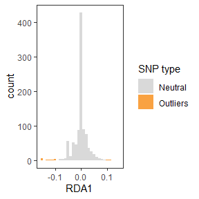

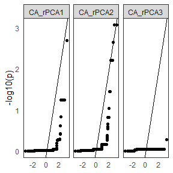

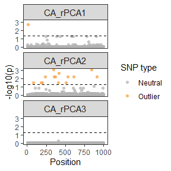

[output not shown]

[output cut: 505 more lines]

```
##                                  .lxk:
##                                 'x0kXXc
##                              .;dXMMMMMO.
##                          .,lkXWMMMWNWO'
##    .;clool:.      ..,clox0NMMMWXXXo\/
##   dXWKxxWKKKxoodkOKNWMMMMMMXO0k\/
##   MM0xxOxMMMMMMMMMMMMMWOdkc\/
##   MMXxxxxMMMMMMMWMXdldkc\/      LFMM done!
##   MMMMMMMMMMMN0xooo;\/
##   MMMMMMMMMMWOoc/\ /\ /\ /\ /\ /\ /\ /\ /\
##   MMAPBMMMMMMMMMMEACMMMWWMWWWMIJWWWWWWKXWX
## ~~~ WWWWWWWWWWWWWWWWWWWWWWWWWWWWWWWWWWWWW ~~~
##  ~~~~~~~~~~~~~~~~~~~~~~~~~~~~~~~~~~~~~~~~~~~
##   ~~~~~~~~~~~~~~~~~~~~~~~~~~~~~~~~~~~~~~~~
##
```

The `do_everything_for_me()` function returns a list with each analysis’s results as objects named according to the method. These formats are identical to those obtained when running respective “do_everything” functions (e.g., `tess_do_everything()` function output is identical to that within the `tess` object).

For methods with model selection (e.g., GDM and MMRR), the default of `do_everything_for_me()` is to run with model selection (`"best"`), and if no significant variables are found, the function will revert to running the `"full"` model for these methods.